# Homework 3: Samplers

Hilde Younce

2024-11-07

# Homework 3: Samplers - Hilde Younce

**Honor Pledge:** On my honor as a student, I have neither given nor received unauthorized aid on this assignment.

```r
library(Rmpfr)
```

```r
library(ggplot2)
library(dplyr)
dat = read.csv("coaldisasters-ds6040.csv")
```

## Part 1: Changepoint detection and samplers

```r
# Gibbs sampler (from stubs)
gibbs_sampler = function(iter, dat, a_mu, b_mu, a_lambda, b_lambda){

  mu_vec = vector()
  lambda_vec = vector()
  k_prob_mat = matrix(nrow = iter+1, ncol = 111)
  k_samp_vec = vector()
  #Initialize sampler
  mu_vec[1] = rgamma(1,a_mu, rate  = b_mu)
  lambda_vec[1] = rgamma(1,a_lambda, rate = b_lambda)
  k_prob_mat[1,] = rep(1/111, 111)
  k_samp_vec[1] = 56

  #Sampler
  for(i in 2:(iter+1)){
    mu_vec[i] = rgamma(1, a_mu + sum(dat$Count[1:k_samp_vec[i-1]]), k_samp_vec[i-1] + b_mu)
    lambda_vec[i] = rgamma(1, a_lambda + sum(dat$Count[(k_samp_vec[i-1]+1):nrow(dat)]),
                           112 - k_samp_vec[i-1] + b_lambda)

    l_temp = vector()
  for(j in 1:111){
      l_temp[j] = sum(log(mpfr(dpois(dat[1:j,2], lambda = rep(mu_vec[i],j)), precBits = 100))) +
      sum(log(.mpfr(dpois(dat[(j+1):112,2], lambda = rep(lambda_vec[i],112-j)), precBits = 100)))
    }
    l_temp <- mpfr(l_temp, precBits = 100)
    k_prob_mat[i,] = as.numeric(exp(l_temp)/sum(exp(l_temp)))
    k_samp_vec[i] = sample(size = 1,1:111, prob = k_prob_mat[i,])
  }
  toReturn = data.frame(mu = mu_vec, lambda = lambda_vec, k = k_samp_vec)

  return(toReturn)
}

# Changed number of iterations from 1000 to 500 because R was crashing
test = gibbs_sampler(500, dat, a_mu = 1, b_mu = 1, a_lambda = 1, b_lambda = 1)
```

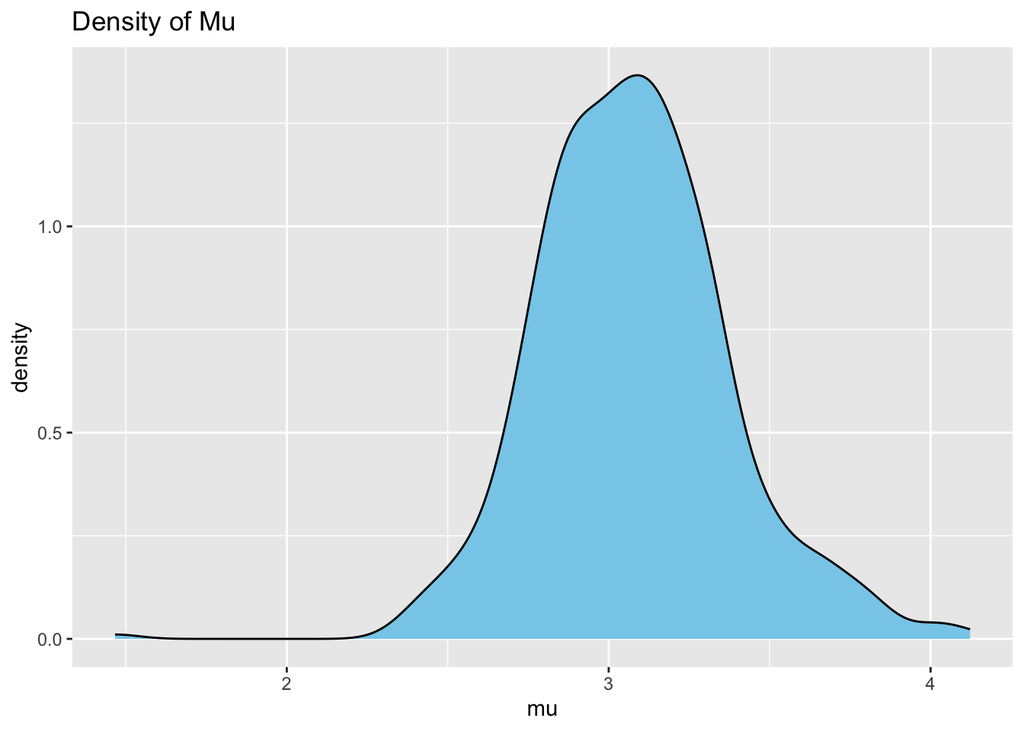

```r
# Plot posterior densities
test %>% ggplot(aes(x=mu)) + geom_density(fill = "skyblue") + labs(title="Density of Mu")
```

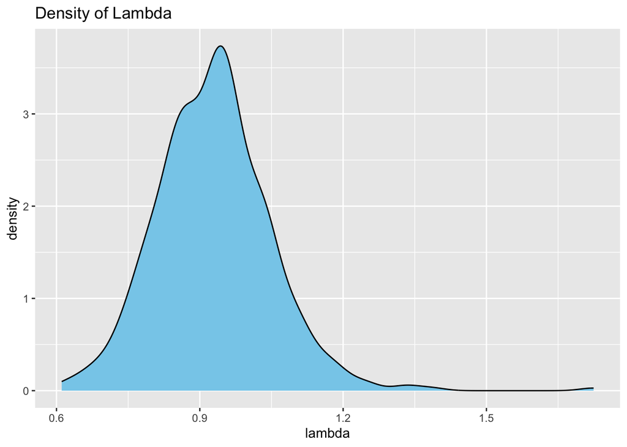

```r
test %>% ggplot(aes(x=lambda)) + geom_density(fill = "skyblue") + labs(title="Density of Lambda")
```

```r
# EAP and confidence intervals

# Mu
mu_EAP <- mean(test$mu)
mu_CI <- quantile(test$mu, probs = c(0.025, 0.975))

# Lambda
lambda_EAP <- mean(test$lambda)
lambda_CI <- quantile(test$lambda, probs = c(0.025, 0.975))

cat("EAP estimate for mu:", mu_EAP, "\n")
```

```
## EAP estimate for mu: 3.076396
```

```r
cat("95% Credible Interval for mu:", mu_CI, "\n")
```

```
## 95% Credible Interval for mu: 2.5325 3.752929
```

```r
cat("EAP estimate for lambda:", lambda_EAP, "\n")
```

```
## EAP estimate for lambda: 0.9290112
```

```r
cat("95% Credible Interval for lambda:", lambda_CI, "\n")
```

```
## 95% Credible Interval for lambda: 0.7127182 1.175689
```

```r
# 5 most probable values of k
test$diff = abs(test$mu - test$lambda)
test %>% arrange(desc(diff)) %>% head(5)
```

```
##         mu    lambda  k     diff
## 1 4.122757 0.8556759 39 3.267081
## 2 4.040197 0.8515101 39 3.188687
## 3 3.754598 0.6160581 36 3.138540
## 4 3.759425 0.7096209 36 3.049804
## 5 3.851457 0.8023556 39 3.049102
```

**a) Describe your findings. What do these EAP and credible intervals imply? And what was the most likely year of the changepoint?**

**b) Why is an EAP or credible interval not necessarily the most appropriate thing to report for the year of the changepoint?**

EAP and credible intervals may not provide the best insight when we are trying to locate a changepoint because they give a single summary of the distribution of mu and lambda. Taking a summary over a long period of time may mask specific moments in time where there were drastic changes, and misrepresent the data with a single mean value. Finally, credible intervals offer bounds but do not pinpoint the exact moment of a changepoint.

## Part 2: Bayesian Logistic Regression with brms

```r
library(brms)
library(caret)
# Load and transform data
wine_train <- read.csv('whitewine-training-ds6040-1.csv')
wine_test <- read.csv('whitewine-testing-ds6040.csv')
wine_train$wine_quality <- ifelse(wine_train$wine_quality == "A", 1, 0)
wine_test$wine_quality <- ifelse(wine_test$wine_quality == "A", 1, 0)
```

```r
# Get combinations of 3 predictors
predictors <- setdiff(names(wine_test), "wine_quality")
combos <- combn(predictors, 3, simplify = FALSE)

results_df <- data.frame(
  combinations = character(0),
  class_rate = numeric(0),
  class_A_rate = numeric(0)
)
```

```r
# Function to run brms model and calculate classification rates
get_rates<- function(combo){
  formula <- as.formula(paste("wine_quality~", paste(combo, collapse = " + ")))
  log_model <- brm(
    formula = formula,
    data = wine_train,
    family = bernoulli(),
    silent = 2
  )

  preds <- fitted(log_model, newdata=wine_test[,!(colnames(wine_test)=="wine_quality")], type = "response")
  preds <- if_else(preds[,1] > 0.1, 1, 0)
  class_rate <- mean(preds==wine_test$wine_quality)
  class_A <- wine_test$wine_quality == 1
  class_A_rate <- mean(preds[class_A] == wine_test$wine_quality[class_A])

  return(list(
    combinations = paste(combo, collapse = ", "),
    class_rate = class_rate,
    class_A_rate = class_A_rate
  ))
}
```

```r
# Test combinations of predictors
for (combo in combos) {
  rates <- get_rates(combo)
  results_df <- rbind(results_df, as.data.frame(rates, stringsAsFactors = FALSE))
}
```

[output not shown]

[output cut: 110 more lines]

[output not shown]

```r
# Best overall classification
sorted_class <- results_df[order(-results_df$class_rate), ]
sorted_class[1,]
```

```
##                                   combinations class_rate class_A_rate
## 1 fixed.acidity, volatile.acidity, citric.acid  0.9534884            0
```

```r
# Best classification for class A
sorted_class <- results_df[order(-results_df$class_A_rate), ]
sorted_class[1,]
```

```
##                                     combinations class_rate class_A_rate
## 120 residual.sugar, free.sulfur.dioxide, alcohol  0.9209302         0.35
```

```r
# Logistic Regression Model 1
log_model <- brm(
    formula = wine_quality ~ fixed.acidity + chlorides + sulphates,
    data = wine_train,
    family = bernoulli(),
    silent = 2
  )
```

```
## Trying to compile a simple C file
```

[output not shown]

```r
summary(log_model)
```

```
##  Family: bernoulli
##   Links: mu = logit
## Formula: wine_quality ~ fixed.acidity + chlorides + sulphates
##    Data: wine_train (Number of observations: 3178)
##   Draws: 4 chains, each with iter = 2000; warmup = 1000; thin = 1;
##          total post-warmup draws = 4000
##
## Regression Coefficients:
##               Estimate Est.Error l-95% CI u-95% CI Rhat Bulk_ESS Tail_ESS
## Intercept        -3.68      0.13    -3.95    -3.44 1.00     3369     2736
## fixed.acidity    -0.22      0.11    -0.43    -0.00 1.00     4204     2541
## chlorides        -1.01      0.23    -1.48    -0.57 1.00     3303     3028
## sulphates         0.01      0.10    -0.19     0.20 1.00     3550     2502
##
## Draws were sampled using sampling(NUTS). For each parameter, Bulk_ESS
## and Tail_ESS are effective sample size measures, and Rhat is the potential
## scale reduction factor on split chains (at convergence, Rhat = 1).
```

```
## No divergences to plot.
```

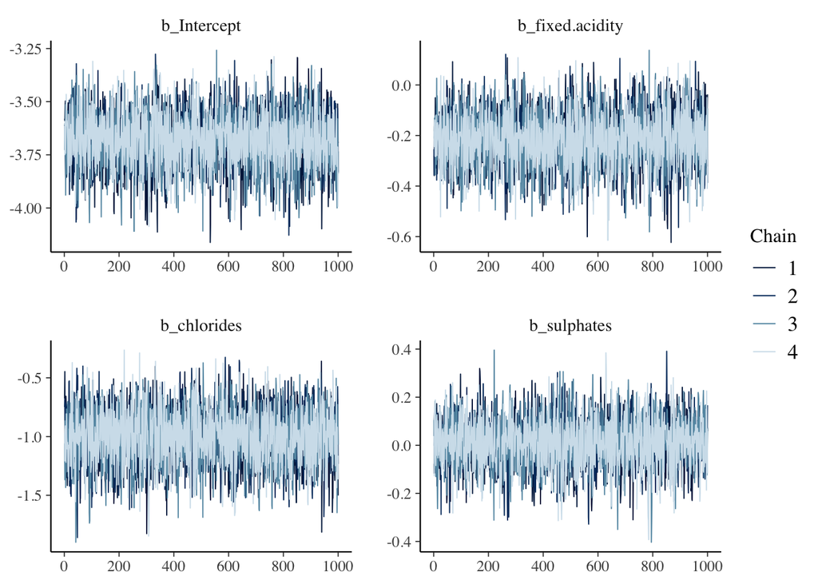

```r
# Trace plot for model 1
stanplot(log_model, type = "trace")
```

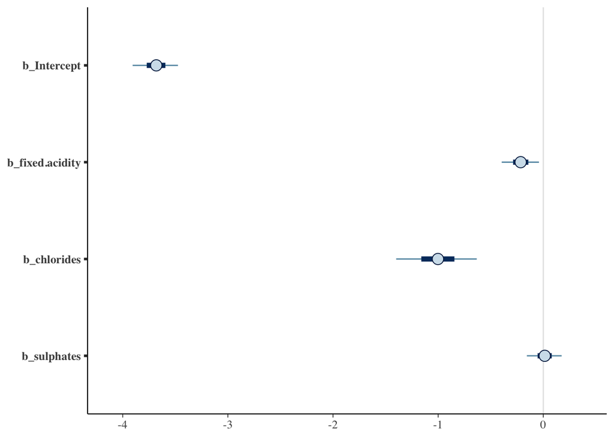

```r
# Forest plot for model 1
stanplot(log_model, type="intervals")
```

```r
# Logistic Regression Model 2
log_model <- brm(
    formula = wine_quality ~ residual.sugar + free.sulfur.dioxide + alcohol,
    data = wine_train,
    family = bernoulli(),
    silent = 2
  )
```

```
## Trying to compile a simple C file
```

[output not shown]

```r
summary(log_model)
```

```
##  Family: bernoulli
##   Links: mu = logit
## Formula: wine_quality ~ residual.sugar + free.sulfur.dioxide + alcohol
##    Data: wine_train (Number of observations: 3178)
##   Draws: 4 chains, each with iter = 2000; warmup = 1000; thin = 1;
##          total post-warmup draws = 4000
##
## Regression Coefficients:
##                     Estimate Est.Error l-95% CI u-95% CI Rhat Bulk_ESS Tail_ESS
## Intercept              -3.89      0.14    -4.17    -3.62 1.00     2880     2628
## residual.sugar          0.23      0.11     0.00     0.44 1.00     3533     2679
## free.sulfur.dioxide     0.32      0.09     0.13     0.50 1.00     3161     2664
## alcohol                 1.04      0.11     0.82     1.27 1.00     2297     2747
##
## Draws were sampled using sampling(NUTS). For each parameter, Bulk_ESS
## and Tail_ESS are effective sample size measures, and Rhat is the potential
## scale reduction factor on split chains (at convergence, Rhat = 1).
```

```
## No divergences to plot.
```

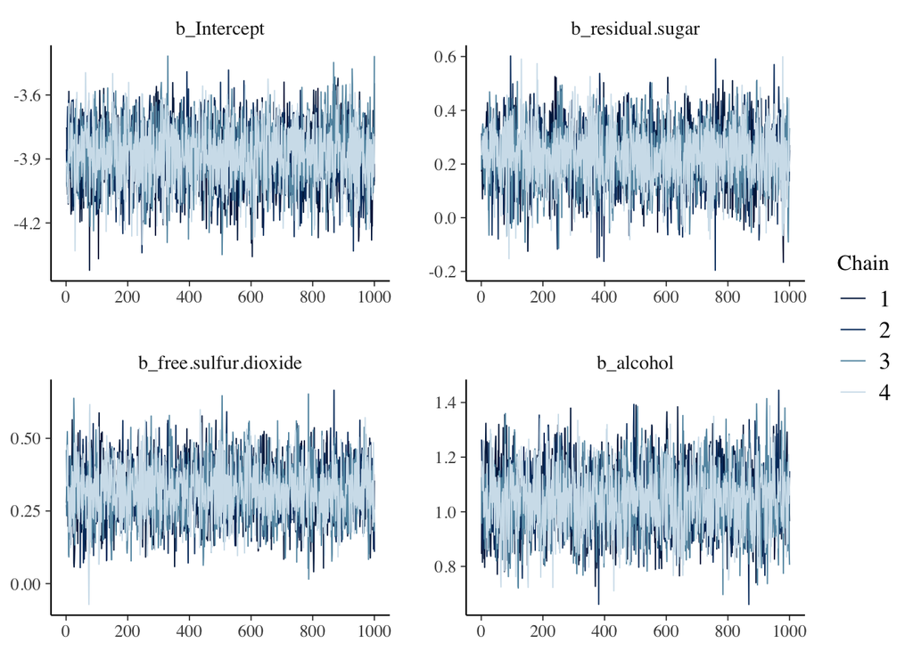

```r
# Trace plot for model 2
stanplot(log_model, type = "trace")
```

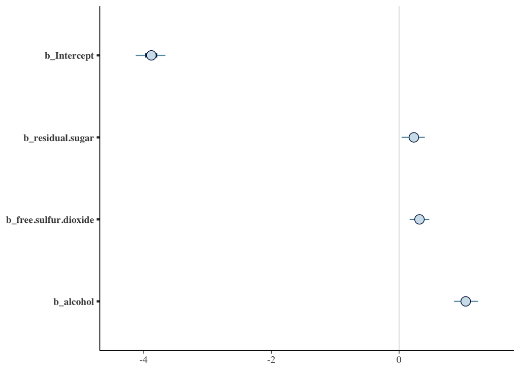

```r
# Forest plot for model 2
stanplot(log_model, type = "intervals")
```

**Discuss your findings. Examine your parameter distributions and explain what those estimates mean, and how they compare to one another. Don’t forget to interpret the intercept as well.**

Model 1: Looking at the summary of our model, a negative intercept value -3.69 indicates that in the absence of other factors a wine is more likely to be classified as 0 instead of 1. For our predictors, negative values for fixed.acidity and chlorides suggests that higher acidity and chloride levels are associated with lower odds of a wine being classified as a 1. Additionally, the 95% credible intervals are negative and do not include zero, meaning that they are likely statistically significant predictors. On the other hand, the relationship of sulphates on wine quality is weaker because the 95% credible interval includes zero. Finally, Rhat values of 1.00 and high values for Bulk_ESS and Tail_ESS suggest that our model has good precision and has converged well for each parameter.

Model 2: As in the first model, a negative intercept of -3.88 indicates that a wine is more likely to be classified as a 0 rather than a 1. Positive coefficient values for residual.sugar, free.sulfur.dioxide and alcohol all suggest that higher quantities of those predictors are associated with a better probability of a wine being classified as an A. The coefficient for alcohol is especially high, indicating a strong relationship between high alcohol content and grade A wines. Out of these predictors, residual.sugar is the least significant due to its credible interval containing zero.